# Angular Momentum Coupling in Many-Electron Atoms

Author

Daniel Fischer

# Introduction

In the previous chapter, we examined how atomic shells and subshells fill up across the periodic table, leading to the characteristic electron configurations of the elements. So far, however, we have treated these configurations as if all electrons with the same quantum numbers had the same energy.

In reality, even within a single configuration, there can be **multiple energy levels**, arising from different ways in which the individual **orbital** and **spin angular momenta** of electrons combine. This **coupling of angular momenta** is a key feature of many-electron atoms and gives rise to the concept of **atomic terms** — groups of closely related energy levels characterized by their total angular momenta.

This chapter introduces the physical principles that determine how the individual angular momenta of electrons couple, what the resulting term symbols mean, and how coupling schemes evolve from light to heavy atoms.

# 1. Terms and Angular Momentum Coupling

In an atom containing several electrons, each electron contributes an **orbital angular momentum** $\hat{\vec{\ell}}_i$ and a **spin angular momentum** $\hat{\vec{s}}_i$. The total Hamiltonian of the atom can be written schematically as

$$\hat{H} = \hat{H}_{\text{Coulomb}} + \hat{H}_{\text{SO}} + \hat{H}_{\text{other}},$$

where  
- $\hat{H}_{\text{Coulomb}}$ describes the electrostatic interactions between electrons and the nucleus,  
- $\hat{H}_{\text{SO}}$ accounts for **spin–orbit coupling**, and  
- $\hat{H}_{\text{other}}$ includes smaller relativistic and hyperfine corrections.

The relative strength of these terms determines the **order in which the individual angular momenta couple**. In light atoms, where the electron–electron interaction dominates over spin–orbit coupling, the most appropriate scheme is **$L$–$S$ coupling** (also called **Russell–Saunders coupling**). In heavy atoms, the strong spin–orbit interaction makes **$jj$ coupling** more appropriate.

Understanding which coupling scheme applies allows us to predict the structure of atomic energy levels and to label them consistently using **term symbols** such as ${}^{2S+1}L_J$.

## 1.1 $L$–$S$ coupling

In the $L$–$S$ (Russell–Saunders) coupling scheme, all orbital angular momenta $\hat{\vec{\ell}}_i$ of the individual electrons are first added to form a **total orbital angular momentum**

$$\hat{\vec{L}} = \sum_i \hat{\vec{\ell}}_i,$$

and all spin angular momenta $\hat{\vec{s}}_i$ are added to form the **total spin**

$$\hat{\vec{S}} = \sum_i \hat{\vec{s}}_i.$$

Finally, these two vectors couple to form the **total angular momentum**

$$\hat{\vec{J}} = \hat{\vec{L}} + \hat{\vec{S}}.$$

Each resulting atomic state is labeled by its quantum numbers $L$, $S$, and $J$, and written in the **term symbol** notation:

$${}^{2S+1}L_J.$$

Here:  
- The **multiplicity** $2S + 1$ gives the number of possible spin projections,  
- The **letter code** for $L$ follows the same convention as before:  
$L = 0, 1, 2, 3, 4, \dots \Rightarrow S, P, D, F, G, \dots$,  
- and $J$ specifies the total angular momentum.

In many-electron atoms, **only unfilled subshells** contribute to $L$, $S$, and $J$. Electrons in closed shells are paired with opposite $m_\ell$ and $m_s$ values, so their total contributions cancel:

$$\sum_{\text{closed shell}} m_\ell = \sum_{\text{closed shell}} m_s = 0.$$

Hence, the **open subshells** determine the observable magnetic and spectroscopic properties of the atom.

## 1.2 $jj$ coupling

When the spin–orbit interaction becomes comparable to or larger than the electrostatic electron–electron interaction, as is the case in **heavy atoms**, a different coupling order becomes appropriate.

In **$jj$ coupling**, each electron’s individual orbital and spin angular momenta first combine to form a total angular momentum

$$\hat{\vec{j}}_i = \hat{\vec{\ell}}_i + \hat{\vec{s}}_i,$$

and the total angular momentum of the atom is obtained by vectorially adding these single-electron momenta:

$$\hat{\vec{J}} = \sum_i \hat{\vec{j}}_i.$$

This scheme is particularly relevant for heavy elements such as lead (Pb), where the spin–orbit splitting within a single subshell (for example, $p_{1/2}$ and $p_{3/2}$) can exceed the energy differences between subshells with different $n$.

## 1.3 Evolution from $L$–$S$ to $jj$ coupling

The figure below illustrates how the coupling of angular momenta evolves across the elements of **group VI** in the periodic table — from carbon ($Z=6$) to lead ($Z=82$). Each column represents the energies of the excited configurations of the type $np\,(n+1)s$, plotted relative to their mean energy.

In light atoms such as carbon, the **Coulomb interaction** between electrons is much stronger than the **magnetic interactions** responsible for spin–orbit and spin–spin coupling. The energy levels are therefore best described within the $L$–$S$ coupling scheme (Russell–Saunders coupling), where all orbital angular momenta $\ell_i$ first combine to a total orbital angular momentum $L$, and all spins $s_i$ combine to a total spin $S$. Only then does the relatively weak spin–orbit interaction split these terms into fine-structure levels characterized by the total angular momentum $J$, giving rise to the familiar singlet (${}^1P_1$) and triplet (${}^3P_{0,1,2}$) terms.

As the atomic number increases, the spin–orbit interaction grows roughly as $Z^4$, and the fine-structure splitting between levels with different $J$ becomes more pronounced. In **heavier elements** such as tin and lead, the coupling scheme transitions toward the **$jj$ regime**, where each electron’s individual $j_i = \ell_i + s_i$ is first formed and then combined. The resulting level structure consists of **two doublets**, which can be interpreted as arising from the coupling of a $p_{1/2}$ or $p_{3/2}$ electron with an $s_{1/2}$ electron.

This smooth transition from the singlet–triplet pattern in carbon to the $jj$-coupled doublets in lead clearly demonstrates how relativistic effects reshape atomic structure as we move to heavier elements.

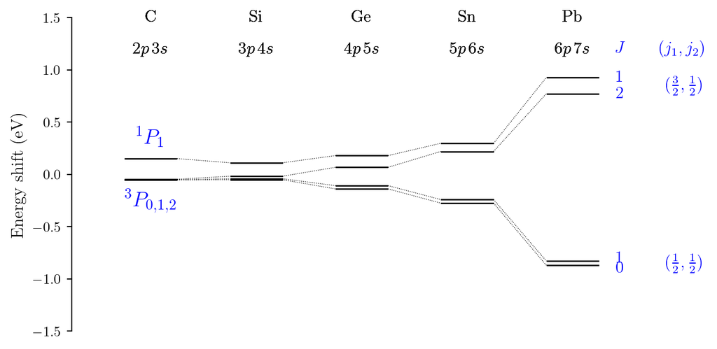

```python
# label: fig-ls-to-jj-transition
# fig-cap: Evolution of angular momentum coupling across the $np\,(n+1)s$ configurations of group VI elements. The weak spin–orbit interaction in carbon produces ${}^1P_1$ and ${}^3P_{0,1,2}$ terms typical of $L$–$S$ coupling, whereas the strong spin–orbit splitting in lead results in two $jj$-coupled doublets characterized by $(j_1,j_2) = (1/2,1/2)$ and $(3/2,1/2)$.
import matplotlib.pyplot as plt
import numpy as np


plt.rcParams['text.usetex'] = True
plt.rcParams['font.family'] = 'serif'
plt.rcParams['font.size'] = 10


# Create the figure and axes
fig, ax = plt.subplots(figsize=(8, 4))

# Energies of np (n+1)s configurations of elements in group VI
terms = [
    ('C', r'$2p\,3s$', [7.48039414,7.48277598,7.48779869,7.68476777]),
    ('Si',r'$3p\,4s$', [4.9200852,4.9296471,4.9537952,5.0823459]),
    ('Ge',r'$4p\,5s$', [4.64341768,4.67449011,4.85000174,4.96191710]),
    ('Sn',r'$5p\,6s$', [4.2949066,4.32881927,4.78937023,4.86725425]),
    ('Pb',r'$6p\,7s$', [4.33447622,4.37505823,5.97462861,6.12973122]),
]

connect_to=np.zeros(4)

# Add orbital text to the plot
x_pos=0
for element, config, level in terms:
    mean_e=np.mean(level)
    for i in range (len(level)):
        ax.text(x_pos + 0.25,1.5, element, ha='center', va='center', fontsize=12, fontweight='bold')
        ax.text(x_pos + 0.25,1.2, config, ha='center', va='center', fontsize=12)
        ax.hlines(level[i]-mean_e, x_pos, x_pos+0.5, color='black', linewidth=1)
        if (connect_to[i]!=0):
            ax.plot([x_pos-.5,x_pos], [connect_to[i], level[i]-mean_e],  color='black', linewidth=0.5, ls=':')
        connect_to[i]=level[i]-mean_e
    if (element=='C'):
        ax.annotate(
            r'$^3P_{0,1,2}$',
            (0.25, level[1]-mean_e),
            textcoords='offset fontsize',
            xytext=(0, -1),
            ha='center',
            va='center',
            fontsize=15,
            fontweight='bold',
            color='blue'
        )
        ax.annotate(
            r'$^1P_1$',
            (0.25, level[3]-mean_e),
            textcoords='offset fontsize',
            xytext=(0, 1),
            ha='center',
            va='center',
            fontsize=15,
            fontweight='bold',
            color='blue'
        )
    if (element=='Pb'):
        J=['0','1','2','1']
        i=0
        for jlevel in J:
            if (i==0): offset=-6
            elif (i==1): offset=5
            else: offset=0
            ax.annotate(
                jlevel,
                (x_pos+0.5, level[i]-mean_e),
                textcoords='offset pixels',
                xytext=(40, offset),
                ha='center',
                va='center',
                fontsize=12,
                fontweight='bold',
                color='blue'
            )
            i+=1
        ax.text(x_pos + 0.7,1.2, r'$J$', ha='center', va='center', color='blue', fontsize=12)
        ax.text(x_pos + 1.3,1.2, r'$(j_1, j_2)$', ha='center', va='center', color='blue', fontsize=12)
        ax.text(x_pos + 1.32,.5*(level[2]+level[3])-mean_e, r'$(\frac{3}{2},\frac{1}{2})$', ha='center', va='center', color='blue', fontsize=12)
        ax.text(x_pos + 1.32,.5*(level[0]+level[1])-mean_e, r'$(\frac{1}{2},\frac{1}{2})$', ha='center', va='center', color='blue', fontsize=12)
    x_pos +=1




ax.set_ylabel('Energy shift (eV)', fontsize=12)
ax.set_xticks([])
# Remove the grid and frame
ax.spines['top'].set_visible(False)
ax.spines['right'].set_visible(False)
ax.spines['bottom'].set_visible(False)

# Set plot limits and hide axes
ax.set_xlim(-0.5, 5.5)
ax.set_ylim(-1.5, 1.5)

# Display the plot
plt.show()
```

However, simply summing the $\ell_i$ and $s_i$ does not account for the Pauli exclusion principle. The principle restricts which combinations of $L$ and $S$ are physically allowed for electrons in the same subshell, which is the focus of the next section.

# 2. Exchange Symmetry of Coupled Electrons in the Same Subshell

When two or more electrons are coupled, the **Pauli exclusion principle** imposes a fundamental constraint:

> The **total wavefunction** must be **antisymmetric** under the exchange of any two electrons.

For two electrons that means

$$\hat P_{12} \Psi(1,2) = -\Psi(1,2).$$

If we express the total wavefunction as a product of a **spatial part** and a **spin part**,

$$\Psi(1,2) = \Phi_{\text{spatial}}(1,2)\, \chi_{\text{spin}}(1,2),$$

then their exchange properties must satisfy:

$$\hat P_{12} \Phi_{\text{spatial}} = \pm \Phi_{\text{spatial}}, \qquad
\hat P_{12} \chi_{\text{spin}} = \mp \chi_{\text{spin}}.$$

That is, if the spatial part is **symmetric**, the spin part must be **antisymmetric**, and vice versa.

This requirement links the **allowed combinations of $L$ and $S$**:

- States with **even** spatial exchange symmetry can only occur with **antisymmetric** spin states.
- States with **odd** spatial exchange symmetry can only occur with **symmetric** spin states.

Hence, for two **equivalent electrons** (i.e., electrons in the same subshell with identical $n$ and $\ell$ quantum numbers), **not all combinations of $L$ and $S$ are allowed**. The Pauli principle eliminates those for which the total wavefunction would be symmetric.

> *Note: The restriction only governs **equivalent electrons**. If the electrons occupy different subshells (they are **non-equivalent**, such as $2s^1\,2p^1$), their exchange does not impose any a priori restrictions on the possible values of $L$ and $S$.*

## 2.1 Symmetry under Exchange

Each coupled angular momentum state—whether spatial ($L$ from $\ell_i$) or spin ($S$ from $s_i$)—has a definite **exchange symmetry**. Let’s consider the case of **two equivalent electrons** with angular momenta $j_1 = j_2$ (where $j$ could stand for $\ell$ or $s$).

For such a pair, the two-particle state with total angular momentum $J$ transforms under particle exchange as:

$$\hat P_{12} \, |(j_1 j_2) J M_J\rangle = (-1)^{2j - J} |(j_1 j_2) J M_J\rangle.$$

Thus, the **exchange parity** (symmetric or antisymmetric) depends only on the value of $J$:

- If $(-1)^{2j - J} = +1$, the state is **symmetric** under exchange.
- If $(-1)^{2j - J} = -1$, the state is **antisymmetric**.

**NoteStep-by-step derivation**

**1. Expand the coupled state in the product basis.**
By definition the coupled state $|(j_1 j_2) J M\rangle$ is a linear combination of product states $|j_1 m_1\rangle|j_2 m_2\rangle$ with Clebsch–Gordan coefficients:
$$|(j_1 j_2) J M\rangle
= \sum_{m_1,m_2} C^{J M}_{\,j_1 m_1;\, j_2 m_2}\; |j_1 m_1\rangle |j_2 m_2\rangle,$$
where the sum runs over $m_1+m_2=M$.

**2. Apply the exchange operator to the product basis.**
The exchange operator $\hat P_{12}$ simply swaps the single-particle states:
$$\hat P_{12}\,|j_1 m_1\rangle |j_2 m_2\rangle = |j_2 m_2\rangle |j_1 m_1\rangle .$$
Hence
$$\hat P_{12}\,|(j_1 j_2) J M\rangle
= \sum_{m_1,m_2} C^{J M}_{\,j_1 m_1;\, j_2 m_2}\; |j_2 m_2\rangle |j_1 m_1\rangle .$$

**3. Use the symmetry property of Clebsch–Gordan coefficients.**
A standard symmetry of Clebsch–Gordan coefficients (equivalently of Wigner 3-j symbols) is
$$C^{J M}_{\,j_1 m_1;\, j_2 m_2}
= (-1)^{\,j_1+j_2-J}\; C^{J M}_{\,j_2 m_2;\, j_1 m_1}.$$
(One can see this either from the known symmetry properties of 3-j symbols or from explicit tables; it is a textbook identity.)

Replace the coefficient in the previous sum:
$$\hat P_{12}\,|(j_1 j_2) J M\rangle
= (-1)^{\,j_1+j_2-J}\!\!\sum_{m_1,m_2} C^{J M}_{\,j_2 m_2;\, j_1 m_1}\; |j_2 m_2\rangle |j_1 m_1\rangle .$$

**4. Recognize the coupled state with reordered labels.**
The sum on the right is precisely the coupled state $|(j_2 j_1) J M\rangle$. Therefore
$$\hat P_{12}\,|(j_1 j_2) J M\rangle = (-1)^{\,j_1+j_2-J}\; |(j_2 j_1) J M\rangle.$$

**5. Specialize to identical angular momenta $j_1=j_2=j$.**
If $j_1=j_2=j$ then $|(j_2 j_1) J M\rangle = |(j_1 j_2) J M\rangle$ (the labeling is identical), and we obtain the desired result:
$$\boxed{\;\hat P_{12}\,|(j j) J M\rangle = (-1)^{\,2j-J}\,|(j j) J M\rangle\;}.$$

This gives the exchange parity: symmetric when $(-1)^{2j-J}=+1$, antisymmetric when $(-1)^{2j-J}=-1$.

**Short plausibility / intuition.**  
- For the *maximum* total $J_{\max}=2j$ the exponent $2j-J_{\max}=0$, so the state is symmetric (no sign change) — intuitively this is the most “aligned” combination and is spatially symmetric.  
- Lowering $J$ effectively introduces antisymmetric combinations in the coupling, so the parity alternates as $J$ decreases.

## 2.2 Application to Spin and Orbital Coupling

Let’s apply this rule to the **spin** and **orbital** subsystems separately.

### (a) Spin coupling ($s = \tfrac{1}{2}$)

For two spins $s_1 = s_2 = \tfrac{1}{2}$, we can form:

- $S = 1$ (triplet): $(-1)^{2s - S} = (-1)^{1 - 1} = +1$ → **symmetric** spin state
- $S = 0$ (singlet): $(-1)^{1 - 0} = -1$ → **antisymmetric** spin state

Hence, the triplet spin state is symmetric and the singlet spin state is antisymmetric under exchange.

### (b) Orbital coupling ($\ell_1 = \ell_2 = \ell$)

For two equivalent orbital angular momenta $\ell$, the same formula gives:

$$\hat P_{12} |(\ell_1 \ell_2) L M_L\rangle = (-1)^{2\ell - L} |(\ell_1 \ell_2) L M_L\rangle.$$

Therefore:

- For **largest $L = 2\ell$**, the state is **symmetric**.
- As $L$ decreases, the exchange symmetry **alternates** between symmetric and antisymmetric.

This pattern can be summarized:

| $L$ | Exchange symmetry | Example ($p^2$, $\ell=1$) |
| --- | --- | --- |
| 2 | symmetric | ${}^1D$ |
| 1 | antisymmetric | ${}^3P$ |
| 0 | symmetric | ${}^1S$ |

## 2.3 Generalization

This alternation of exchange symmetry with decreasing $L$ or $S$ is a general feature of coupled angular momenta:

**TipExchange symmetry two equivalent and coupled angular momenta**

For two equivalent angular momenta $j_1 = j_2 = j$, the coupled state $J$ has exchange symmetry
$$\hat P_{12} = (-1)^{2j - J}.$$
Thus, **the highest $J$ state is symmetric**, and the symmetry alternates as $J$ decreases.

This rule is a cornerstone for determining which $L$–$S$ combinations are **allowed** for equivalent electrons (such as $p^2$, $d^2$, etc.)—and thus underpins the **term structure** and **Hund’s rules** that follow.

> **Important Note:**  
> This symmetry restriction applies **only to electrons within the same subshell**, where exchange of two electrons does not change the configuration (e.g., both are $2p$ electrons). If the electrons occupy **different subshells** (such as $2s$ and $2p$), exchange changes the orbital part of the state, and one can always construct an overall antisymmetric wavefunction—for instance, as a **Slater determinant**. Therefore, the even/odd $L$–$S$ symmetry rule is relevant **only for equivalent electrons**.

# 3. Ground-State Terms and Hund’s Rules

In the previous section we introduced the concept of **term symbols** that describe how the angular momenta of several electrons combine to form the total quantum numbers $L$, $S$, and $J$. A natural next question is:

> **Given an electron configuration, which of its possible terms corresponds to the lowest energy — i.e., the atomic ground state?**

This section addresses exactly that question. We will see that the relative ordering of the terms within a given configuration is not arbitrary but follows a set of empirical guidelines known as **Hund’s rules**.

The figure below illustrates how electrons fill the available orbitals for the first ten elements of the periodic table. From these configurations, we will determine the corresponding **ground-state terms** by systematically applying Hund’s rules.

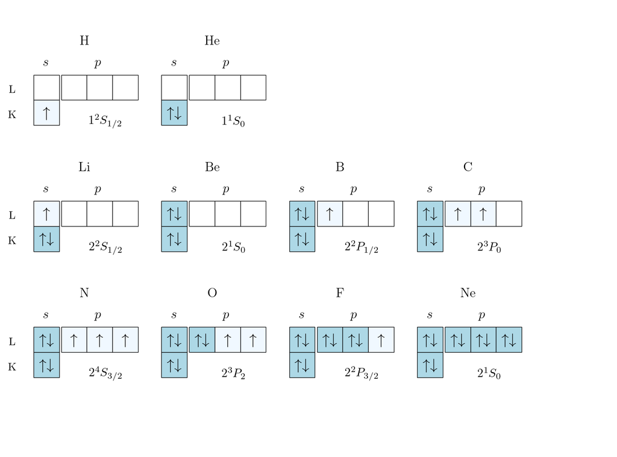

```python
# fig-cap: Electron configurations and ground-state terms for H–Ne. Each box represents an orbital (either $s$ or $p$), and arrows denote electron spins. According to Hund’s rules, orbitals are filled to maximize total spin and orbital angular momentum before pairing occurs.
import matplotlib.pyplot as plt
import matplotlib.patches as patches

plt.rcParams['text.usetex'] = True
plt.rcParams['font.family'] = 'serif'
plt.rcParams['font.size'] = 15


fig, ax = plt.subplots(figsize=(8, 6))
ax.set_xlim(0, 14)
ax.set_ylim(-4.5, 6)
ax.axis('off')

def draw_orbital_box(ax, x, y, width=0.6, height=0.6, filled=False, filled_once=False, arrows=''):
    """Draw a single orbital box with optional electron arrows"""
    color = 'aliceblue' if filled_once else ('lightblue' if filled else 'white')
    rect = patches.Rectangle((x, y), width, height, linewidth=0.5,
        edgecolor='black', facecolor=color)
    ax.add_patch(rect)

    # Add arrows for electrons
    if arrows:
        ax.text(x + width/2, y + height/2, arrows, ha='center', va='center',
               fontsize=14, fontweight='bold')

def draw_element_config(ax, x_start, y_start, element, s1_config, s2_config, p2_config, term_symbol):
    """Draw complete electron configuration for an element"""
    box_size = 0.6
    spacing = 0.65


    # Element label
    ax.text(x_start + 1.2, y_start + 2.2, element, ha='center', va='center',
           fontsize=12, fontweight='bold')

    # Orbital labels
    ax.text(x_start + 0.3, y_start + 1.7, r'$s$', ha='center', va='center', fontsize=12)
    if len(p2_config) > 0:
        ax.text(x_start + 1.5, y_start + 1.7, r'$p$', ha='center', va='center', fontsize=12)

    # s1 orbital
    draw_orbital_box(ax, x_start, y_start + 0.2, box_size, box_size,
                    filled=(s1_config != ''), filled_once=(s1_config.count('↑') + s1_config.count('↓')==1), arrows=s1_config)

    # s2 orbital
    draw_orbital_box(ax, x_start, y_start + 0.8, box_size, box_size,
                    filled=(s2_config != ''), filled_once=(s2_config.count('↑') + s2_config.count('↓')==1), arrows=s2_config)

    # p2 orbitals
    for i, p_arrows in enumerate(p2_config):
        draw_orbital_box(ax, x_start + spacing + i*box_size, y_start + 0.8,
                        box_size, box_size, filled=(p_arrows != ''), filled_once=(p_arrows.count('↑') + p_arrows.count('↓')==1), arrows=p_arrows)

    # Term symbol
    ax.text(x_start + 1.7, y_start + 0.3, term_symbol, ha='center', va='center',
           fontsize=11)

# Period 1
draw_element_config(ax, 0.5, 3, 'H', '↑', '', ['', '', ''], r'1$^2S_{1/2}$')
draw_element_config(ax, 3.5, 3, 'He', '↑↓', '', ['', '', ''], r'1$^1S_0$')

# Period 2
y_pos = 0
elements = [
    ('Li', '↑↓', '↑', ['', '', ''], r'2$^2S_{1/2}$', 0.5),
    ('Be', '↑↓', '↑↓', ['', '', ''], r'2$^1S_0$', 3.5),
    ('B', '↑↓', '↑↓', ['↑', '', ''], r'2$^2P_{1/2}$', 6.5),
    ('C', '↑↓', '↑↓', ['↑', '↑', ''], r'2$^3P_0$', 9.5),
    ('N', '↑↓', '↑↓', ['↑', '↑', '↑'], r'2$^4S_{3/2}$', 0.5),
    ('O', '↑↓', '↑↓', ['↑↓', '↑', '↑'], r'2$^3P_2$', 3.5),
    ('F', '↑↓', '↑↓', ['↑↓', '↑↓', '↑'], r'2$^2P_{3/2}$', 6.5),
    ('Ne', '↑↓', '↑↓', ['↑↓', '↑↓', '↑↓'], r'2$^1S_0$', 9.5),
]

for element, s1_conf, s2_conf, p2_conf, term, x_pos in elements:
    if (element=='N'): y_pos=-3
    draw_element_config(ax, x_pos, y_pos, element, s1_conf, s2_conf, p2_conf, term)

# Add quantum number labels on the left
ax.text(0, 3.45, 'K', ha='center', va='center', fontsize=10, fontweight='bold')
ax.text(0, 4.05, 'L', ha='center', va='center', fontsize=10, fontweight='bold')

ax.text(0, .45, 'K', ha='center', va='center', fontsize=10, fontweight='bold')
ax.text(0, 1.05, 'L', ha='center', va='center', fontsize=10, fontweight='bold')

ax.text(0, -2.55, 'K', ha='center', va='center', fontsize=10, fontweight='bold')
ax.text(0, -1.95, 'L', ha='center', va='center', fontsize=10, fontweight='bold')

plt.tight_layout()
plt.show()
```

Each box represents a specific one-electron state characterized by the quantum numbers $(n, \ell, m_\ell)$, which can be occupied by up to two electrons with opposite spin orientations ($m_s = \pm \tfrac{1}{2}$).

> **Remark:** Although neither $m_\ell$ nor $m_s$ are good quantum numbers once electron–electron and spin–orbit interactions are included, the corresponding product states still form a **complete basis**. The actual eigenstates of the atomic Hamiltonian can be constructed from this basis using **Clebsch–Gordan coefficients**, as discussed in the section on Angular Momenta and Their Couplings.

### 3.1 Hund’s Rules

Hund’s rules provide an empirical but remarkably successful way to predict which term corresponds to the **lowest energy** for a given electron configuration:

**TipHund’s Rules**

1. **Maximum multiplicity:**  
   The term with the **largest total spin** $S$ lies lowest in energy. This minimizes Coulomb repulsion between electrons because parallel spins avoid each other more effectively due to the Pauli exclusion principle.
2. **Maximum $L$ for a given $S$:**  
   Among terms with the same $S$, the one with the **largest total orbital angular momentum** $L$ lies lowest. Larger $L$ corresponds to configurations where electrons are on average farther apart in space.
3. **Ordering by $J$ (spin–orbit coupling):**  
   The level with the **smallest $J = L - S$** lies lowest for **less than half-filled** subshells; the **largest $J = L + S$** lies lowest for **more than half-filled** subshells. This rule follows from the magnetic spin–orbit interaction, whose sign reverses across the half-filled point.

### 3.2 Interpreting the Figure

The figure illustrates how these rules apply to the first ten elements:

- **Hydrogen ($1s^1$):**  
  With one $s$ electron ($\ell=0$), we have $L=0$ and $S=\tfrac{1}{2}$, giving the term ${}^2S_{1/2}$.
- **Helium ($1s^2$):**  
  The two $s$ electrons must have opposite spins to satisfy the Pauli principle, so $S=0$ and $L=0$. The term is ${}^1S_0$.
- **Lithium ($1s^2 2s^1$):**  
  The outer $2s$ electron behaves hydrogen-like. With $\ell=0$ and $S=\tfrac{1}{2}$, we again have ${}^2S_{1/2}$.
- **Beryllium ($1s^2 2s^2$):**  
  The $2s$ subshell is filled; paired spins give $S=0$, $L=0$, hence ${}^1S_0$.
- **Boron ($1s^2 2s^2 2p^1$):**  
  The single $p$ electron ($\ell=1$) gives $L=1$ and $S=\tfrac{1}{2}$, so ${}^2P_{1/2,3/2}$. By Hund’s third rule (less than half-filled), ${}^2P_{1/2}$ lies lowest.
- **Carbon ($1s^2 2s^2 2p^2$):**  
  Now there are two $p$ electrons. To maximize $S$, we give them **parallel spins** ($m_s=+\tfrac{1}{2}$ each) and place them in **different** orbitals, e.g., $m_\ell=+1$ and $m_\ell=0$. The total spin is $S=1$, and combining $m_\ell=+1$ and $m_\ell=0$ gives $L=1$ (a $P$ term). Thus the dominant term is ${}^3P$. Because the subshell is less than half-filled, Hund’s third rule makes ${}^3P_0$ the lowest level.
- **Nitrogen ($1s^2 2s^2 2p^3$):**  
  With three equivalent $p$ electrons, we can place one in each $m_\ell=-1,0,+1$ orbital, all with parallel spins ($m_s=+\tfrac{1}{2}$). This gives the maximum spin $S=\tfrac{3}{2}$ and a perfectly balanced orbital distribution $L=0$, i.e. a ${}^4S_{3/2}$ ground term — a hallmark of half-filled shells.
- **Oxygen ($1s^2 2s^2 2p^4$):**  
  Four $p$ electrons can be described equivalently as two *holes* in an otherwise filled $p^6$ shell. These two holes yield the **same set of possible $L$ and $S$ values** as two $p$ electrons (so the same multiplet types, e.g. ${}^3P$, ${}^1D$, ${}^1S$), but the **$J$-ordering** within a given multiplet is reversed for more-than-half-filled subshells. Consequently, although the multiplet for $p^4$ matches that of $p^2$, Hund’s third rule predicts that the level with **largest** $J$ (here ${}^3P_2$) lies lowest.
- **Fluorine ($1s^2 2s^2 2p^5$):**  
  One hole in a $p^6$ shell is analogous to one $p$ electron in terms of the available multiplet (a ${}^2P$ term), but since the subshell is more than half filled the fine-structure ordering is reversed: the ground level is ${}^2P_{3/2}$ rather than ${}^2P_{1/2}$.
- **Neon ($1s^2 2s^2 2p^6$):**  
  The $p$ subshell is completely filled, yielding $S=0$, $L=0$, and ${}^1S_0$.

The figure highlights how Hund’s rules govern the balance between **spin alignment** and **orbital occupancy**, giving rise to the observed term symbols and explaining the stability of half-filled and closed subshells.

## 3.3 Physical Origin of Hund’s Rules

Hund’s rules emerge from the interplay between **electrostatic (Coulomb)** and **magnetic (spin–orbit and spin–spin)** interactions:

- The **first two rules** follow from electron–electron Coulomb repulsion. Parallel spins (large $S$) and high orbital angular momentum ($L$) minimize the average repulsion energy by maximizing electron separation in space and spin.
- The **third rule** results from the **magnetic spin–orbit interaction**, which couples each electron’s spin to its orbital motion. For less than half-filled shells, aligning $\vec{L}$ and $\vec{S}$ (large $J$) increases the total energy; for more than half-filled shells, the reverse holds.

As atomic number increases, spin–orbit coupling becomes stronger, and Hund’s rules gradually give way to the **$jj$ coupling** picture. Together, these simple rules provide a remarkably accurate guide to the structure of atomic ground states throughout much of the periodic table.